# CA_MCD_URCODE

Created by FDN 8.5.2014; Edited by: LAB 1.17.2017 for Morne Patate; LC 12.4.2017 Hermitage phases; FDN 12.21.2018 more tidy; fixed MCD function to handle phases; CP and EB 5.28.2019 Comments and Section editing for UR code; Converted to Rmd by Beth Sawyer

June 12, 2019

- Created by: FDN 8.5.2014
- Last update: FDN 8.5.2014
- Edited by: LAB 1.17.2017 for Morne Patate
- Edited by: LC 12.4.2017 Hermitage phases
- Edited by: FDN 12.21.2018 more tidy; fixed MCD function to handle phases.
- Edited by: CP and EB 5.28.2019 Comments and Section editing for UR code
- Converted to RMD: ECS June 2019

```r
library(RPostgreSQL)
library(dplyr)
library(tidyr)
library(reshape2)
library (ca)
library (plotrix)
library(ggplot2)
library(viridis)
library(ggrepel)
```

*Setup* - Establish a DBI connection to DAACS PostgreSQL database and submit SQL queries - Link to file with database password

### 1. Get table ware type date ranges table

```r
MCDTypeTable<- dbGetQuery(DRCcon,'
                          SELECT *
                          FROM "tblCeramicWare"
                          ')
```

### 2. Submit an SQL query

- Note the use of ’' as an escape sequence
- Builds a table of ceramics data
- Generate a summary table of that data
- Compute ceramic totals

```r
wareTypeData<-dbGetQuery(DRCcon,'
                         SELECT
                         "public"."tblCeramic"."Quantity",
                         "public"."tblCeramicWare"."Ware",
                         "public"."tblCeramicGenre"."CeramicGenre",
                         "public"."tblCeramicCEWType"."CeramicCEWType",
                         "public"."tblProjectName"."ProjectName",
                         "public"."tblContext"."ProjectID",
                         "public"."tblContext"."Context",
                         "public"."tblContextDepositType"."DepositType",
                         "public"."tblContext"."DAACSStratigraphicGroup",
                         "public"."tblContext"."MasterContextNumber",
                         "public"."tblContext"."FeatureNumber",
                         "public"."tblContextFeatureType"."FeatureType",
                         "public"."tblContext"."QuadratID",
                         "public"."tblContext"."DAACSPhase"
                         FROM
                         "public"."tblProjectName"
                         INNER JOIN  "public"."tblProject" ON "public"."tblProject"."ProjectNameID" =
                         "public"."tblProjectName"."ProjectNameID"
                         INNER JOIN  "public"."tblContext" ON "public"."tblContext"."ProjectID" =
                         "public"."tblProject"."ProjectID"
                         LEFT JOIN "public"."tblContextDepositType" ON "public"."tblContext"."DepositTypeID" =
                         "public"."tblContextDepositType"."DepositTypeID"
                         LEFT JOIN "public"."tblContextFeatureType" ON "public"."tblContext"."FeatureTypeID" =
                         "public"."tblContextFeatureType"."FeatureTypeID"
                         INNER JOIN "public"."tblContextSample" ON "public"."tblContextSample"."ContextAutoID" =
                         "public"."tblContext"."ContextAutoID"
                         INNER JOIN "public"."tblGenerateContextArtifactID" ON "public"."tblContextSample"."ContextSampleID" =
                         "public"."tblGenerateContextArtifactID"."ContextSampleID"
                         INNER JOIN "public"."tblCeramic" ON "public"."tblCeramic"."GenerateContextArtifactID" =
                         "public"."tblGenerateContextArtifactID"."GenerateContextArtifactID"
                         INNER JOIN "public"."tblCeramicWare" ON "public"."tblCeramic"."WareID" =
                         "public"."tblCeramicWare"."WareID"
                         LEFT JOIN "public"."tblCeramicGenre" ON "public"."tblCeramic"."CeramicGenreID" =
                         "public"."tblCeramicGenre"."CeramicGenreID"
                         LEFT JOIN "public"."tblCeramicCEWType" ON "public"."tblCeramic"."CeramicCEWTypeID" =
                         "public"."tblCeramicCEWType"."CeramicCEWTypeID"
                         WHERE
                         "public"."tblContext"."ProjectID" = \'67\'
                         ')
# do a summary
summary1 <- wareTypeData %>%
  group_by(ProjectName,ProjectID,Ware) %>%
  summarise(count = sum(Quantity))
options(tibble.print_min=100)
summary1
```

```
## # A tibble: 30 x 4
## # Groups:   ProjectName, ProjectID [?]
##    ProjectName    ProjectID Ware                                count
##    <chr>          <chr>     <chr>                               <int>
##  1 South Pavilion 67        American Stoneware                     17
##  2 South Pavilion 67        Astbury Type                            1
##  3 South Pavilion 67        Black Basalt                            2
##  4 South Pavilion 67        Bristol Glaze Stoneware                 3
##  5 South Pavilion 67        British Stoneware                      30
##  6 South Pavilion 67        Buckley-type                            2
##  7 South Pavilion 67        Canary Ware                             1
##  8 South Pavilion 67        Coarse Earthenware, unidentified        4
##  9 South Pavilion 67        Creamware                             288
## 10 South Pavilion 67        Delftware, Dutch/British               15
## 11 South Pavilion 67        Fulham Type                             1
```

[output cut: 19 more lines]

```r
#compute the total count of ceramics
AllCeramicCount <- summary1 %>% summarise(Count=sum(count))
```

### 3. Customizations: Ware Type dates or names

The following code chunks are optional. - Since they are optional, the code chunks are written with a command that allows them to be read here in the code but not in the rendered document. They are also set not to run when the code is run in its entirety; this is the same as ‘commenting them out,’ as done with hashtags in raw r code. - If you want to use this section of the code, then change the r code header to read ‘eval = TRUE, include=TRUE’

#### 3.1 Change beginning and end dates

For example, the CEW types don’t have manufacturing dates so they can be excluded from MCDs but it can be useful to include them in the CA and compare the CA order with them in and the CA order that doesn’t include them. - Set a minimal start date for all types based on project-specific information, such as this example for French Coarse Earthenwares; - This may bite you later if new start dates are >= end dates

#### 3.2 Replace ware types with CEWs Types

- Optional
- For example, replace ‘Caribbean CEW’ ware type with applicable CEW Type.
- Change r header as described above if you want to include this chunk.

#### 3.3. Ware type summary

Do a quick summary of the new ware type totals if you run either of the sections above.

### 4. Compute new numeric date variables

Compute midpoint, manufacturing span, and inverse variance for each ware type based on existing variables. Add new columns to house those variables; these are needed to calculate the MCD.

```r
MCDTypeTable <- MCDTypeTable %>%
  mutate(midPoint = (EndDate+BeginDate)/2,
         span = (EndDate - BeginDate),
         inverseVar = 1/(span/6)^2
  )
```

### 5. Subset by deposit type

Here you have the option to remove contexts with deposit types such as ‘Cleanup’ and ‘Surface Collection,’ which might help with cleaning data. As with section 3, change the r header to ‘eval=TRUE, include=TRUE’ if you want to use this section of code.

### 6. Create the UNIT Variable

The UNIT variable contains the level at which assemblages are aggregated in the analysis. You will need to cutomize this logically for *YOUR* site. There are circumstances where it will make the most sense to group by SGs or Features, but in others you may need to use Contexts only. - *Note* you should use *ONE*, and only one, option; either **6.1, 6.2, 6.3, or 6.4.**  
- Change the r header for the one used to ‘eval=TRUE, include=TRUE.’ - The rest should be left with the r header as ‘eval=FALSE, include=FALSE.’ - Note that we create a new dataframe: wareTypeData_Unit.

First some housekeeping so we do not stumble on the confusion between R’s NA or nulls. NAs or nulls values are typically present after reading the data in from the SQL language. This must be done regardless of which aggreagation method you choose.

```r
wareTypeData$DAACSStratigraphicGroup[is.na(wareTypeData$DAACSStratigraphicGroup)] <- ''
wareTypeData$FeatureNumber[is.na(wareTypeData$FeatureNumber)] <- ''
wareTypeData$QuadratID[is.na(wareTypeData$QuadratID)] <- ''
```

#### 6.1 Generate Unit Variable with certain conditions

- Use ‘case_when’ command to cycle through Feature, SG, and Context to assign aggregration unit.
- This step assigns a:
  - Context as the ‘unit’ when there is no related feature number or DAACS SG.
  - DAACS SG as the ‘unit’ when there is no feature number but there is a related DAACS SG.
  - Combined Feature Number and Context as the ‘unit’ when there is a related Feature Number but no DAACS SG
  - Combined Feature Number and DAACS SG as the ‘unit’ when there is a related Feature Number and a DAACS SG

```r
wareTypeData_Unit <- wareTypeData %>%
  mutate( unit = case_when(
    FeatureNumber == "" & DAACSStratigraphicGroup == ""
    ~ paste(Context),
    FeatureNumber == "" & DAACSStratigraphicGroup != ""
    ~ paste(DAACSStratigraphicGroup),
    FeatureNumber != "" & DAACSStratigraphicGroup == ""
    ~ paste(FeatureNumber, Context, sep= '.'),
    FeatureNumber != "" & DAACSStratigraphicGroup != ""
    ~ paste(FeatureNumber,DAACSStratigraphicGroup, sep='.')
  ))
```

#### 6.2 Generate Unit Variable as ContextID

Use this to assign ContextID to the ‘unit’ variable (in other words, aggreate assemblages at the context level)

#### 6.3 Generate Unit Variable as QuadratID

Use this to assign QuadratID to the ‘unit’ variable (in other words, aggreate assemblages at the quadrat level)

#### 6.4 Assign Quadrat and Context to the unit

Use this to assign both the QuadratID and the Contect to the ‘unit’ variable.

*Check on the content of the ‘unit’ variable to make sure it is aggregated the way you intended.*

```r
table(wareTypeData_Unit$unit)
```

```
##
##      2582F      2582G      2583L      2584U 2586UNPROV      2590J
##          7          3          9          1          1          1
##   F01.SG47   F03.SG31   F03.SG32   F03.SG33   F03.SG34  F08.2614D
##        790         27         15         45        111          1
##  F10.2582V  F10.2582W  F10.2582X  F10.2582Y  F11.2584Q  F11.2584S
##          1          2          3          9          1          4
##  F11.2588K  F11.2588L  F11.2588M   F11.SG14   F11.SG18   F12.SG17
##          1          1          2          5         17          1
##   F16.SG21  F21.2594I  F21.2595H   F21.SG35   F21.SG36   F21.SG37
##         10          3          5         24          9         25
##   F21.SG38   F21.SG39   F21.SG40   F21.SG41       SG02       SG11
##          5          5          2         55          1          5
##       SG19       SG22       SG25       SG26       SG28       SG30
##          3         30          2          6        190         18
##       SG42       SG43       SG45       SG46       SG48
##         15         30          5         39        115
```

### 7. Transpose Data

The data must be transposed to compute the MCDs and execute CA

```r
wareByUnitT <- wareTypeData_Unit %>% group_by(Ware,unit) %>%
  summarise(count = sum(Quantity)) %>%
  spread(Ware, value=count , fill=0 )
```

### 8. Remove specific ware types; sample size cut off

It is possible at this point to drop types you do not want in the MCD computations or to assign a sample size cut off.

#### 8.1 Drop ware types

- This step is optional, so if you want to use it, change the r header to ‘eval=TRUE, include=TRUE’
- We do this because some types are historical types and some aren’t. If a type isn’t helpful in providing a chronological signal then you should take it out.
- Ex: American SW – it has a very different function than a pearlware plate and therefore its pattern of occurrence is likely to be affected, can get temporal gradiant for Dim1 (REW) vs Dim 2 that is capturing more utilitarian
- One thing: we are doing this before we calculate MCDs, *NOT* the seriation
- Two approaches:
1. Leave them (waretypes) in the MCD dataframe and only take them out of the CA and then when you compare CA to the MCDs (i.e. don’t remove them here).
2. If you take them out here, you will be doing the MCD CA comparison on the same dataset without the given ware types included
- Here we name the types we do *NOT* want included *NOTE: You will need to add the types that are particular to your site to the select function:*

```r
wareByUnitT1 <- wareByUnitT %>% dplyr::select(
  - 'Refined Earthenware, unidentifiable')
```

#### 8.2 Sample size

We may also want to enforce a sample size cut off on the MCD analysis. MCDs and TPQs are more reliable with larger samples, but may be useful in small ones. - DAACS standard is n > 5 for a unit’s total ceramics. - Since this step is highly recommended, the header is formatted with ‘true’ statements. If you do not want to drop any of your ‘units,’ regardless of sample size, the change the r header to read ‘eval=FALSE, include=FALSE.’ *Note the use of column numbers as index values to get the type counts, which are assumed to start in col 2.*

```r
wareByUnitTTotals<- rowSums(wareByUnitT1[,-1])
table(wareByUnitTTotals)
```

```
## wareByUnitTTotals
##   0   1   2   3   4   5   6   7   9  10  14  15  16  19  24  25  29  39
##   1  11   2   4   1   5   2   1   1   2   1   1   1   1   3   1   2   1
##  43  54 111 113 189 780
##   1   1   1   1   1   1
```

```r
wareByUnitT1 <-wareByUnitT1[wareByUnitTTotals > 5,]
# And get rid of any types that do not occur in the subset of assemblages that DO  meet the sample size cutoff
wareByUnitT2 <- wareByUnitT1[,c(T,colSums(wareByUnitT1[,-1])
                                > 0)]
```

### 9. Define functions to Remove Types w/o Dates and Compute MCDs

#### 9.1 Type removal function

We build a function that removes types with no dates, either because they have no dates in the MCDTypeTable or because they are not MCD Ware Types (e.g. they are CEW Types). This approach is useful because it returns a dataframe that contains ONLY types that went into the MCDs, which you may want to analyze using using other methods (e.g. CA). Two arguments: - ‘unitData’: dataframe with counts of ware types in units the left variable IDs the units, while the rest of the varaibles are types - ‘typeData’: a dataframe with at least three variables named ‘Ware’, ‘midPoint’ and ‘inversevar’ containing the manufacturing midpoints and inverse variances for the types. Returns a list comprised of two dataframes: - unitDataWithDates has units with types with dates - typeDataWithDates has the types with dates

```r
RemoveTypesNoDates <- function(unitData,typeData){
#  unitData<- WareByUnitT1
#  typeData <-MCDTypeTable
  typesWithNoDates <- typeData$Ware[(is.na(typeData$midPoint))]

  # types in the MCD table with no dates.
  moreTypesWithNoDates <- colnames(unitData)[-1][! colnames(unitData)[-1] %in%
                                                   typeData$Ware]

  # types in the data that are NOT in the MCD Type table.
  typesWithNoDates <- c(typesWithNoDates, moreTypesWithNoDates)
  unitDataWithDates <- unitData[, ! colnames(unitData) %in%  typesWithNoDates]
  typeDataWithDates <- typeData[! typeData$Ware %in%  typesWithNoDates, ]
  unitDataWithDates <- filter(unitDataWithDates,
                              rowSums(unitDataWithDates[,2:ncol(unitDataWithDates)])>0)
  return(list(unitData = unitDataWithDates,
              typeData = typeDataWithDates))
}
```

```r
dataForMCD <- RemoveTypesNoDates(wareByUnitT2 , MCDTypeTable)
```

#### 9.2 Define function that computes MCDs

Two arguments: - ‘unitData’: a dataframe with the counts of ware types in units. We assume the first column IDs the units, while the rest of the columns are counts of types. - ‘typeData’: a dataframe with at least two variables named ‘midPoint’ and ‘inversevar’ containing the manufacturing midpoints and inverse variances for the types. Returns a list comprise of two dataframes: - ‘MCDs’ has units and the vanilla and BLUE MCDs - ‘midPoints’ has the types and manufacturing midpoints, in the order they appeared in the input ‘unitData’ dataframe.

```r
EstimateMCD<- function(unitData,typeData){
  countMatrix<- as.matrix(unitData[,2:ncol(unitData)])
  originalUnitName <-  colnames(unitData)[1]
  colnames(unitData)[1] <- 'unitID'
  unitID <- (unitData[,1])
  unitID[is.na(unitID)] <-'Unassigned'
  unitData[,1] <- unitID
  nUnits <- nrow(unitData)
  nTypes<- nrow(typeData)
  nTypesFnd <-ncol(countMatrix)
  typeNames<- colnames(countMatrix)

# create two col vectors to hold inverse variances and midpoints in the order in which the type variables occur in the data.
  invVar<-matrix(data=0,nrow=nTypesFnd, ncol=1)
  mPoint <- matrix(data=0,nrow=nTypesFnd, ncol=1)
  for (i in (1:nTypes)){
    for (j in (1:nTypesFnd)){
      if (typeData$Ware[i]==typeNames[j]) {
        invVar[j,]<-typeData$inverseVar[i]
        mPoint[j,] <-typeData$midPoint[i]
      }
    }
  }
  # get a unit by type matrix of inverse variances
  invVarMat<-matrix(t(invVar),nUnits,nTypesFnd, byrow=T)
  # a matrix of weights
  blueWtMat<- countMatrix * invVarMat
  # sums of the weight
  sumBlueWts <- rowSums(blueWtMat)
  # the BLUE MCDs
  blueMCD<-(blueWtMat %*% mPoint) / sumBlueWts
  # compute the vanilla MCDs
  sumWts <- rowSums(countMatrix)
  # the vanilla MCDs
  MCD<-(countMatrix %*% mPoint) / sumWts
  # now for the TPQs
  meltedUnitData <- gather(unitData, key = Ware, value=count,- unitID)
  meltedUnitData <- filter(meltedUnitData, count > 0)
  mergedUnitData <- inner_join(meltedUnitData, typeData, by='Ware')
  # the trick is that to figure out the tpq. it's best to have each record (row)
  # represent an individual sherd  but in its current state, each record has
  # a count c:(c > 1). We must generate c records for each original record.
  # Use rep and rownames - rowname is a unique number for each row, kind of
  # like an index. rep() goes through dataframe mergedUnitData and replicates
  # based on the count column, i.e. if count is 5 it will create 5 records or
  # rows and for columns 1 and 6 (col 1 is unit name and 6 is begin date.
  repUnitData <- mergedUnitData[rep(rownames(mergedUnitData ),mergedUnitData$count),c(1,6)]
  # once all the rows have a count of one, we run the quantile function
  TPQ <- tapply(repUnitData$BeginDate,repUnitData$unitID,
                function(x) quantile(x, probs =1.0, type=3 ))
  TPQp95 <- tapply(repUnitData$BeginDate,repUnitData$unitID,
                   function(x) quantile(x, probs = .95 , type=3 ))
  TPQp90 <- tapply(repUnitData$BeginDate,repUnitData$unitID,
                   function(x) quantile(x, probs = .90,  type=3 ))
  # Finally we assemble the results in to a list
  MCDs<-data.frame(unitID, MCD, blueMCD, TPQ, TPQp95, TPQp90, sumWts )
  colnames(MCDs)<- c(originalUnitName,'MCD','blueMCD', 'TPQ', 'TPQp95', 'TPQp90', 'Count')
  midPoints <- data.frame(typeNames,mPoint)
  MCDs <- list('MCDs'=MCDs,'midPoints'=midPoints)
  return(MCDs)
}
```

#### 9.3 Apply the function and view results

```r
MCDByUnit<-EstimateMCD(dataForMCD$unitData, dataForMCD$typeData)
MCDByUnit
```

```
## $MCDs
##                unit      MCD  blueMCD  TPQ TPQp95 TPQp90 Count
## 2582F         2582F 1764.429 1780.603 1762   1762   1660     7
## 2583L         2583L 1793.300 1793.502 1775   1775   1775    10
## F01.SG47   F01.SG47 1828.200 1804.319 1840   1840   1820   772
## F03.SG31   F03.SG31 1860.200 1830.281 1840   1840   1840    25
## F03.SG32   F03.SG32 1820.143 1804.109 1840   1820   1820    14
## F03.SG33   F03.SG33 1879.061 1851.779 1840   1840   1840    41
## F03.SG34   F03.SG34 1824.619 1809.787 1840   1830   1820   109
## F10.2582Y F10.2582Y 1791.000 1791.000 1762   1762   1762    19
## F11.SG18   F11.SG18 1742.087 1780.663 1775   1775   1762    23
## F16.SG21   F16.SG21 1760.000 1760.000 1660   1660   1660    10
## F21.SG35   F21.SG35 1821.292 1810.003 1840   1840   1840    24
## F21.SG36   F21.SG36 1854.444 1826.765 1840   1840   1840     9
## F21.SG37   F21.SG37 1813.562 1800.657 1840   1840   1820    24
## F21.SG41   F21.SG41 1809.755 1797.179 1840   1840   1830    53
## SG11           SG11 1776.583 1787.774 1762   1762   1762     6
## SG22           SG22 1791.140 1798.346 1775   1775   1775    25
## SG26           SG26 1767.083 1790.839 1775   1775   1660     6
## SG28           SG28 1770.106 1786.846 1840   1775   1762   188
## SG30           SG30 1829.033 1822.528 1830   1830   1830    15
## SG42           SG42 1843.643 1819.432 1840   1840   1840    14
## SG43           SG43 1880.724 1855.815 1830   1830   1830    29
## SG46           SG46 1837.392 1808.304 1840   1840   1820    37
## SG48           SG48 1849.049 1808.023 1840   1840   1820   113
##
## $midPoints
##                        typeNames mPoint
## 1             American Stoneware 1835.0
## 2                   Astbury Type 1750.0
## 3                   Black Basalt 1785.0
## 4              British Stoneware 1735.5
## 5                   Buckley-type 1747.5
## 6                    Canary Ware 1807.5
## 7                      Creamware 1791.0
## 8       Delftware, Dutch/British 1701.0
## 9                    Fulham Type 1723.0
## 10       Ironstone/White Granite 1920.0
## 11                Jackfield Type 1765.0
## 12                     Pearlware 1802.5
## 13            Porcelain, Chinese 1760.0
## 14 Porcelain, English Bone China 1897.0
## 15      Porcellaneous/Hard Paste 1910.0
## 16                       Redware 1800.0
## 17              Redware, refined 1840.0
## 18                  Rosso Antico 1732.5
## 19    Tin-Enameled, unidentified 1701.0
## 20              White Salt Glaze 1762.5
## 21                     Whiteware 1910.0
## 22                   Yellow Ware 1885.0
```

### 10. Seriation diagram based on MCDs

First define a function to sort the rows and cols of a matrix based on the orders from two arguments (e.g. MCDs and midpoints) - Arguments: the name of the variable that contains the unit scores (e.g. MCDs) the name of the variable that contains the type score (e.g. the midpoints) the name of the dataframe that contains the counts of ware types in units - Returns: the sorted dataframe

```r
sortData<- function(unitScores,typeScores,unitData){
  sortedData<-unitData[order(unitScores, decreasing=T),]
  sortedData<-sortedData[,c(1,order(typeScores)+1)]
  return(sortedData)
}
unitDataSorted <- sortData(MCDByUnit$MCDs$blueMCD,
                           MCDByUnit$midPoints$mPoint,
                           dataForMCD$unitData)
```

### 11. Make a Ford-style battleship plot

- Convert to a matrix, whose cols are the counts
- Make the unit name a ’rowname" of the matrix

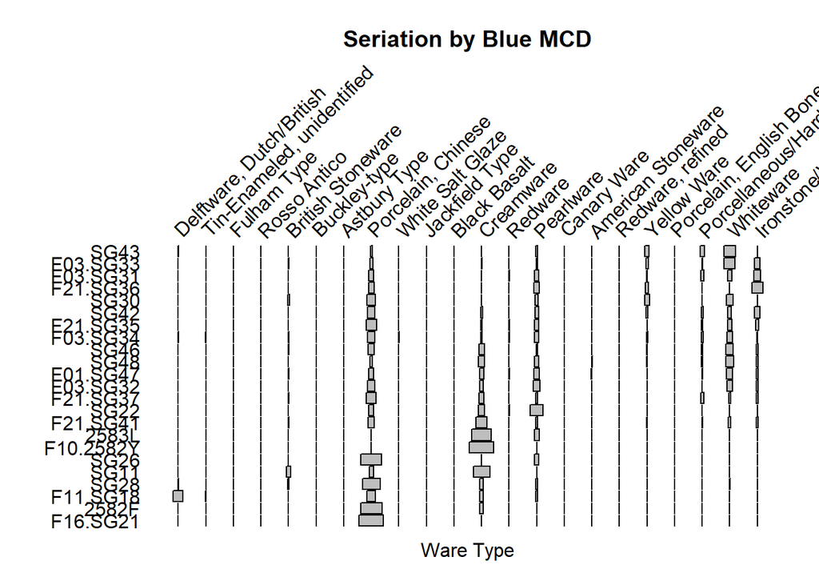

```r
Mat<-as.matrix(unitDataSorted[,2:ncol(unitDataSorted)])
rownames(Mat)<-unitDataSorted$unit
rSums<- matrix (rowSums(Mat),nrow(Mat),ncol(Mat), byrow=F)
MatProp<-Mat/rSums
# Do the plot
battleship.plot(MatProp,
                mar=c(2,6,10,1),
                main = 'Seriation by Blue MCD',
                xlab='Ware Type',
                ylab= 'Context',
                col='grey')
```

### 12. Correspondence Analysis

You need to decide if you want to use exactly the same data that went into the MCD analysis (dataForMCD$unitData), or the data with all the ware types (e.g. if you want to include CEWs/ware types that don’t have dates). To chose, comment out one of these two lines that begin formating for CA: - Use all the data - Use ONLY the data used for MCDs

```r
wareByUnitT_forCA <- wareByUnitT2
#wareByUnitT_forCA <- dataForMCD$unitData
```

#### 12.1 Remove Outliers

**USE THIS SECTION AFTER AN INITIAL CA RUN TO remove types and/or units from the analysis that are outliers**

```r
wareByUnitT_forCA <- wareByUnitT_forCA %>% filter(
  unit != '2581')
```

#### 12.2 Check column totals and remove types (optional)

When you have removed a unit check to see if any of the column totals is now 0. If any exist you will need to remove the ware type, otherwise the CA won’t run.

```r
colSums(wareByUnitT_forCA[,-1])
```

```
##                American Stoneware                      Astbury Type
##                                16                                 1
##                      Black Basalt           Bristol Glaze Stoneware
##                                 2                                 3
##                 British Stoneware                      Buckley-type
##                                29                                 2
##                       Canary Ware  Coarse Earthenware, unidentified
##                                 1                                 4
##                         Creamware          Delftware, Dutch/British
##                               272                                15
##                       Fulham Type           Ironstone/White Granite
##                                 1                                98
##                    Jackfield Type                   Native American
##                                 1                                 2
##                         Pearlware                Porcelain, Chinese
##                               275                               429
##     Porcelain, English Bone China         Porcelain, unidentifiable
##                                 6                                 7
##          Porcellaneous/Hard Paste                           Redware
##                                57                                19
##                  Redware, refined Refined Stoneware, unidentifiable
##                                 2                                 2
##                      Rosso Antico         Stoneware, unidentifiable
##                                 1                                 4
##        Tin-Enameled, unidentified                    Unidentifiable
##                                 2                                 1
##                  White Salt Glaze                         Whiteware
##                                 2                               313
##                       Yellow Ware
##                                29
```

To remove ware types, change to ‘eval=TRUE, include=TRUE.’

#### 12.3 Run the CA

**USE THIS SECTION TO RUN THE INTIAL CA AND THEN USE AGAIN AFTER REMOVING OUTLIERS**

```r
matX <- as.matrix(wareByUnitT_forCA[,-1])
rownames(matX) <- wareByUnitT_forCA$unit
ca1<-ca(matX)
# Summary(ca1) - inertia plot with broken stick
# put the result in dataframes
inertia <- data.frame('Inertia' = prop.table(ca1$sv^2))
rowScores <- data.frame(ca1$rowcoord[,1:5], unit =ca1$rownames)
colScores <- data.frame(ca1$colcoord[,1:5], type =ca1$colnames)
```

#### 12.4 Compute the broken stick model inertia

- Broken stick model shows inertia percentage values would look if distribution was random – i.e. null hypothesis.
- If the inertia values returned by the CA function are showing Dim 1 is capturing significant variation then Dim 1 values from CA will be higher than Dim 1 values from BS and Dim 2 values will be lower than values from BS
- If Dim1 and Dim2 are significant CA, values in CA for both dimensions will be higher than both values in BS.
- One piece of evidence that’s helping you evaluate whether patterning is real
- see https://rdrr.io/rforge/PCDimension/man/brokenStick.html for more information on the broken stick model

```r
broken.stick <- function(p)
  # Compute the expected values of the broken-stick distribution for 'p' pieces.
  # Example: broken.stick.out.20 = broken.stick(20)
  #             Pierre Legendre, April 2007
{
  result = matrix(0,p,2)
  colnames(result) = c("Dim","Expected.Inertia")
  for(j in 1:p) {
    E = 0
    for(x in j:p) E = E+(1/x)
    result[j,1] = j
    result[j,2] = E/p
  }
  result <- result
  return(data.frame(result))
}
bs <- broken.stick(nrow(inertia))
```

#### 12.5 Plot the proportion of inertia

Plot the inertia and save the plot for website chronology page/presentations. Make sure to update file names for this and all subsequent plots

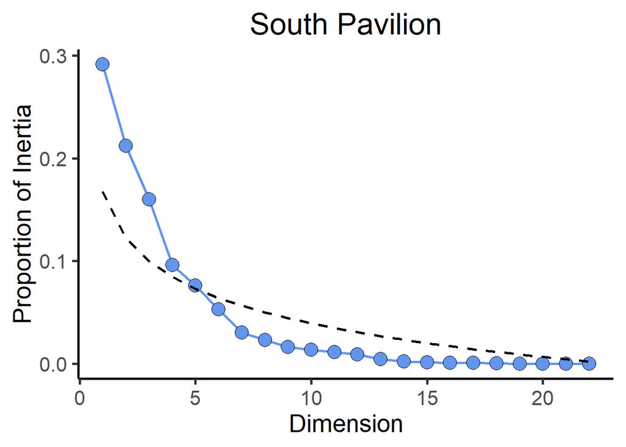

```r
theme_set(theme_classic(base_size = 20))
p <- ggplot(data=inertia , aes(x= 1:length(Inertia), y=Inertia)) +
  # geom_bar(stat="identity", fill="grey") +
  theme(plot.title = element_text(hjust = 0.5))+
  geom_line(col= "cornflower blue", size=1) +
  geom_point(shape=21, size=5, colour="black", fill="cornflower blue") +
  #make sure to update title to proper site name
  labs( title="South Pavilion", x="Dimension", y='Proportion of Inertia' ) +
  geom_line(aes(y = bs[,2], x= bs[,1]), color = "black", linetype = "dashed",
            size=1)
p
```

```r
ggsave("SouthPav_InertiaPlot.png", p, width=10, height=7.5, dpi=300)
```

#### 12.6 Plots of row and column scores for Dim 1 vs. Dim 2 and Dim 1 vs. Dim 3

We are looking to see if Dim1 captures time, keep in mind that time may reside in two dimensions and you may be better off looking for clusters in the Dim1Dim2 scatterplot, removing outliers and running again. It is an iterative process. Save plots for website chronology page/presentations.

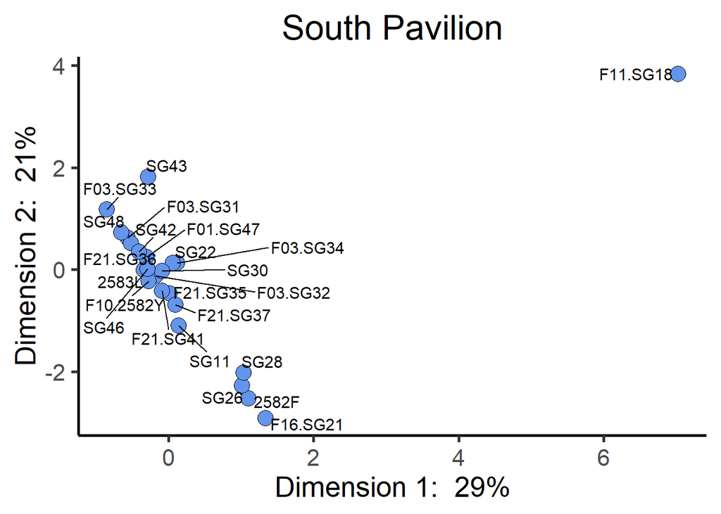

```r
library(ggrepel)
set.seed(42)
p1 <- ggplot(rowScores, aes(x=Dim1,y=Dim2))+
  geom_point(shape=21, size=5, colour="black", fill="cornflower blue")+
  # geom_text(aes(label= unit,vjust=-.6, cex=5) +
  theme(plot.title = element_text(hjust = 0.5))+
  geom_text_repel(aes(label= unit), cex = 4) +
  labs(title="South Pavilion",
       x = paste ("Dimension 1",":  ", round(inertia[1,]*100),'%', sep=''),
       y= paste ("Dimension 2",":  ", round(inertia[2,]*100),'%', sep='')
  )
p1
```

```r
ggsave("SouthPav_Figure1Dim1Dim2_2018cxt.png", p1, width=10, height=7.5, dpi=300)
```

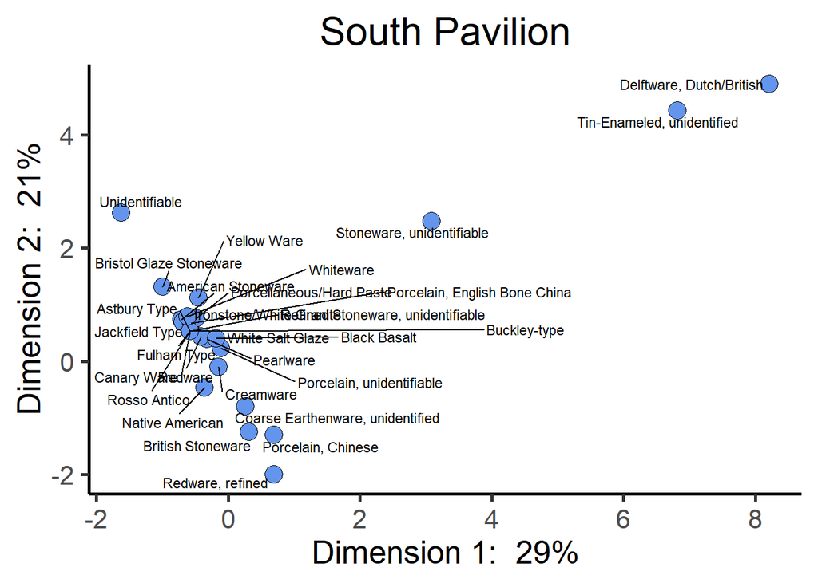

```r
p2 <- ggplot(colScores, aes(x = Dim1,y = Dim2))+
  geom_point(shape=21, size=5, colour="black", fill="cornflower blue")+
  #geom_text(aes(label= type),vjust=-.6, cex=5)+
  theme(plot.title = element_text(hjust = 0.5))+
  geom_text_repel(aes(label=type), cex= 3) +
  labs(title="South Pavilion",
       x = paste ("Dimension 1",":  ", round(inertia[1,]*100),'%', sep=''),
       y= paste ("Dimension 2",":  ", round(inertia[2,]*100),'%', sep='')
  )
p2
```

```r
ggsave("SouthPav_Figure2WareTypes_2018cxt.png", p2, width=10, height=7.5, dpi=300)
```

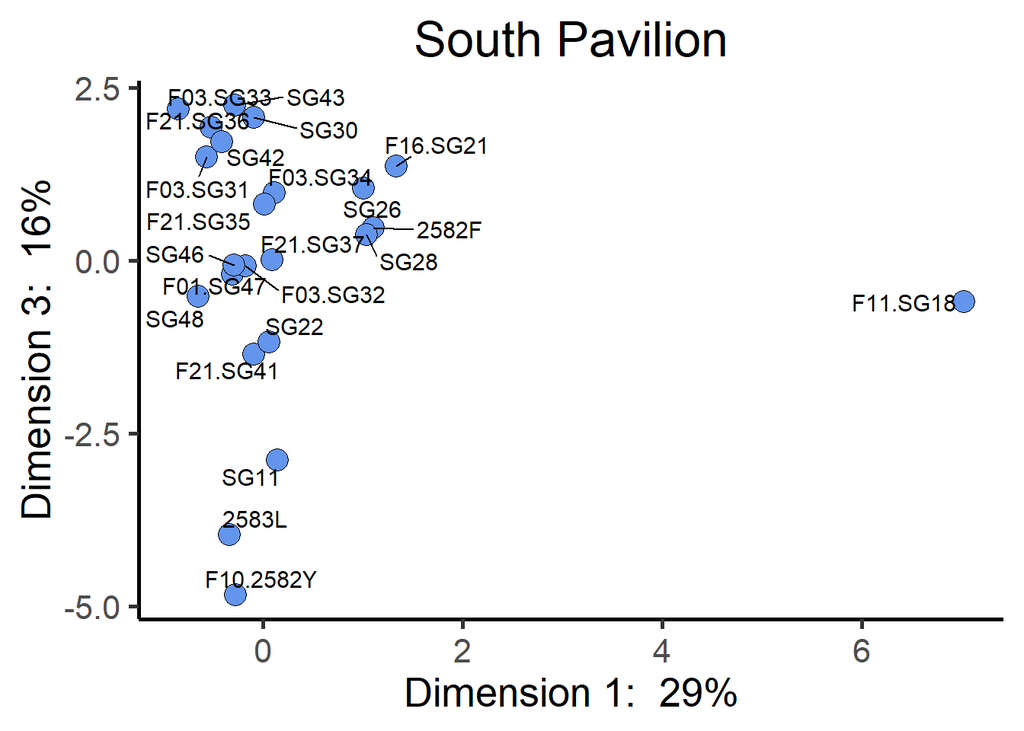

```r
set.seed(42)
p1a <- ggplot(rowScores, aes(x=Dim1,y=Dim3))+
  geom_point(shape=21, size=5, colour="black", fill="cornflower blue")+
  # geom_text(aes(label= unit,vjust=-.6, cex=5) +
  theme(plot.title = element_text(hjust = 0.5))+
  geom_text_repel(aes(label= unit), cex = 4) +
  labs(title="South Pavilion",
       x = paste ("Dimension 1",":  ", round(inertia[1,]*100),'%', sep=''),
       y= paste ("Dimension 3",":  ", round(inertia[3,]*100),'%', sep='')
  )
p1a
```

```r
ggsave("SouthPav_Figure1Dim1Dim3_2018cxt.png", p1, width=10, height=7.5, dpi=300)
```

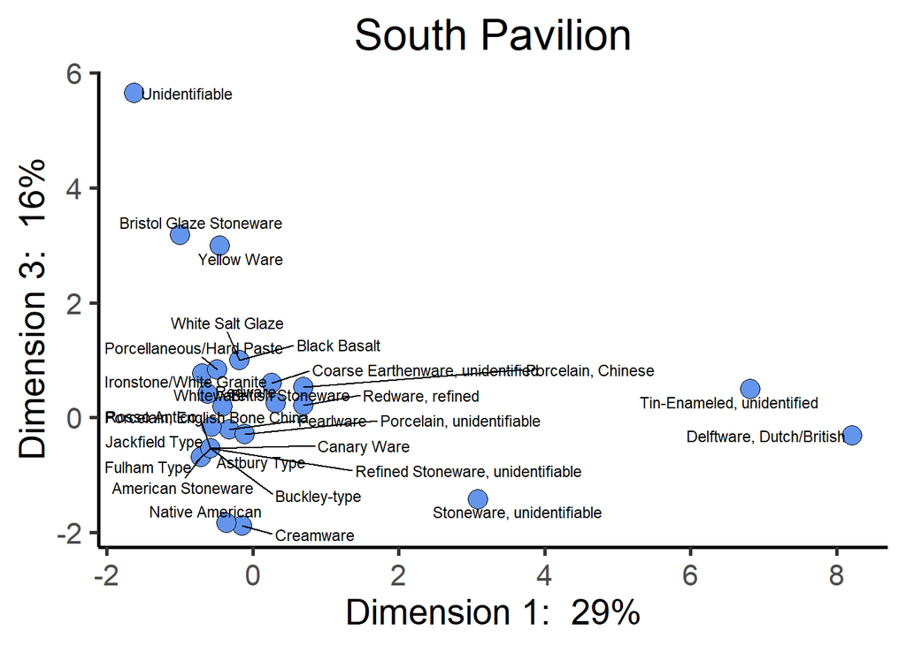

```r
p2a <- ggplot(colScores, aes(x = Dim1,y = Dim3))+
  geom_point(shape=21, size=5, colour="black", fill="cornflower blue")+
  #geom_text(aes(label= type),vjust=-.6, cex=5)+
  theme(plot.title = element_text(hjust = 0.5))+
  geom_text_repel(aes(label=type), cex= 3) +
  labs(title="South Pavilion",
       x = paste ("Dimension 1",":  ", round(inertia[1,]*100),'%', sep=''),
       y= paste ("Dimension 3",":  ", round(inertia[3,]*100),'%', sep='')
  )
p2a
```

```r
ggsave("SouthPav_Figure2Dim1Dim3Wares_2018cxt.png", p2, width=10, height=7.5, dpi=300)
```

#### 12.7 Sort on Dim1 scores and do battleship plot

Sort the data matrix that went into the CA on the dim1 scores and do a battleship plot with the sorted data.

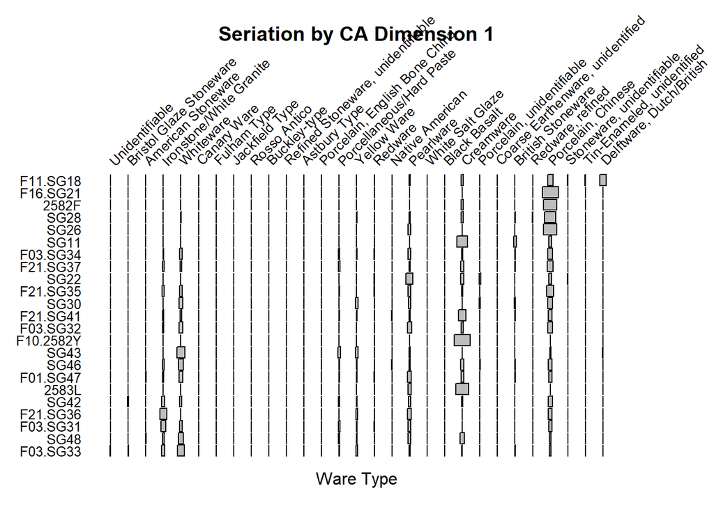

```r
wareByUnitT_Sorted  <- sortData(rowScores$Dim1, colScores$Dim1, wareByUnitT_forCA)
Mat<-as.matrix(wareByUnitT_Sorted[,-1])
rownames(Mat)<-wareByUnitT_Sorted$unit
rSums<- matrix (rowSums(Mat),nrow(Mat),ncol(Mat), byrow=F)
MatProp<-Mat/rSums
SeriationCA<-battleship.plot(MatProp,
                             mar=c(2,4,8,4),
                             cex.labels=.8,
                             main = 'Seriation by CA Dimension 1',
                             xlab='Ware Type',
                             ylab= 'Context',
                             col='grey')
```

```r
SeriationCA
```

```
## $mar
## [1] 2 4 8 4
```

```r
ggsave("SouthPav_SeriationCADim1_2018cxt.png", p2, width=10, height=7.5, dpi=300)
```

### 13. Compare MCD and CA dim scores

Create a data frame of units, counts, and mcds, and then generate plots of CA scores and MCDs. Save plots for website chronology page/presentations

```r
CA_MCD <- inner_join(MCDByUnit$MCDs, rowScores, by='unit' )
```

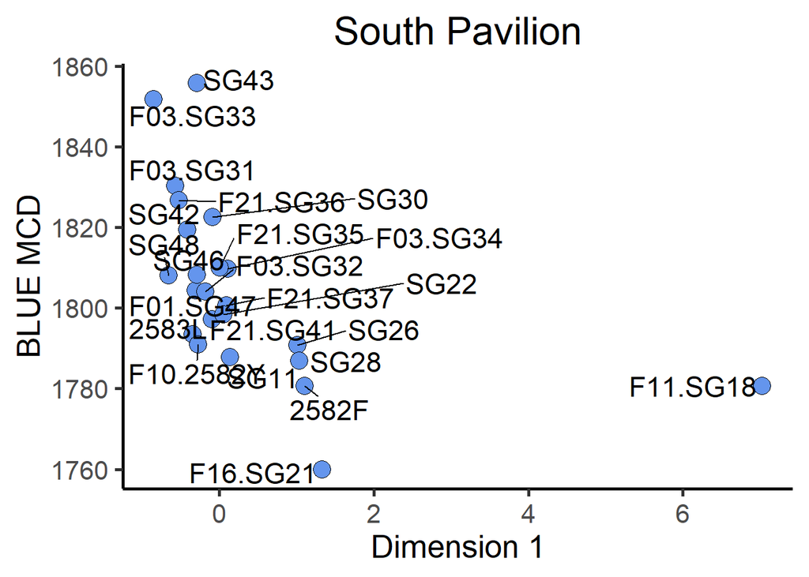

```r
p3 <- ggplot(CA_MCD, aes(x=Dim1,y=blueMCD))+
  geom_point(shape=21, size=5, colour="black", fill="cornflower blue")+
  #geom_text(aes(label=unit),vjust=-.6, cex=5)+
  theme(plot.title = element_text(hjust = 0.5))+
  geom_text_repel(aes(label=unit), cex=6) +
  labs(title="South Pavilion",
       x="Dimension 1",
       y="BLUE MCD")
p3
```

```r
ggsave("SouthPav_Dim1BLUEMCD_2018cxt.png", p3, width=10, height=7.5, dpi=300)
```

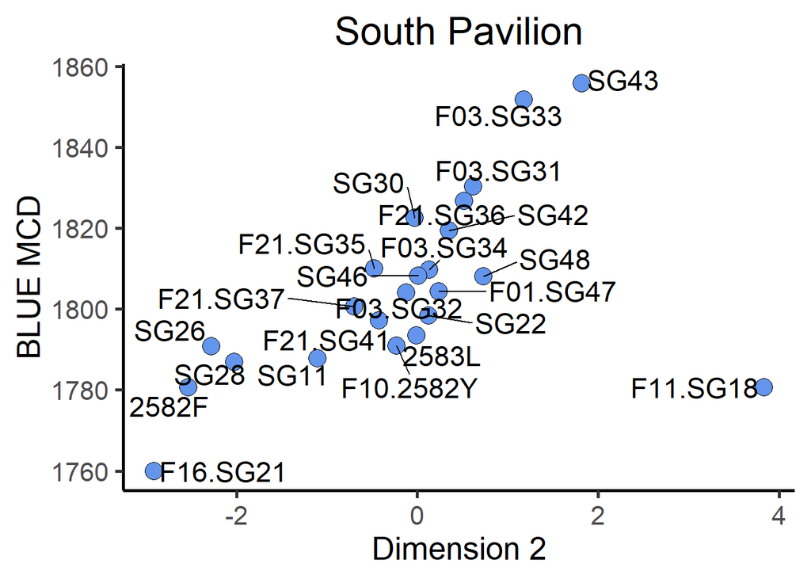

```r
p4 <- ggplot(CA_MCD, aes(x = Dim2,y = blueMCD))+
  geom_point(shape=21, size=5, colour="black", fill="cornflower blue")+
  #geom_text(aes(label=unit),vjust=-.6, cex=5)+
  geom_text_repel(aes(label=unit), cex=6) +
  theme(plot.title = element_text(hjust = 0.5))+
  labs(title="South Pavilion",
       x="Dimension 2",
       y="BLUE MCD")
p4
```

```r
ggsave("SouthPav_Dim2BLUEMCD.png", p4, width=10, height=7.5, dpi=300)
```

### 14. Histogram of Dim 1 scores for Phasing

- This creates a weighted histogram of Dim 1 Scores. Depending on the CA values, you may need to change the scale.
- Add lines for phase breaks *Note: don’t do this until after you have removed outliers*

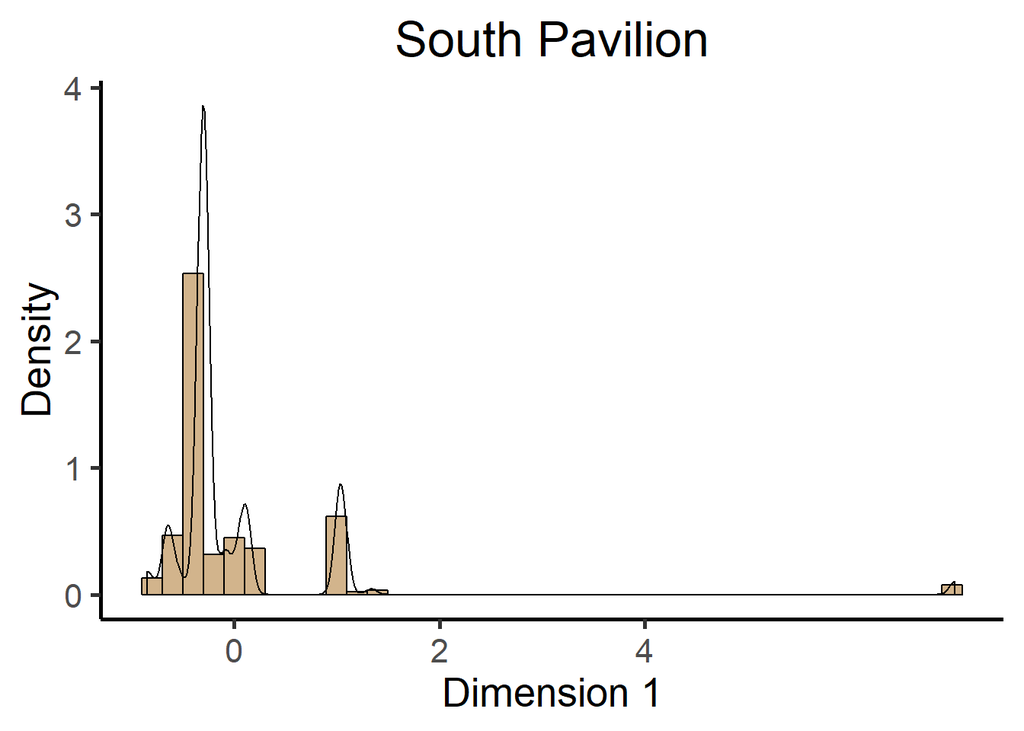

```r
dim1ForHist<- data.frame(dim1 = rep(CA_MCD$Dim1, CA_MCD$Count))
p5 <- ggplot(dim1ForHist, aes(x = dim1)) +
  theme(plot.title = element_text(hjust = 0.5))+
  geom_histogram(aes(y=..density..), colour="black", fill="tan", binwidth=0.2,
                 boundary= .1) +
  scale_x_continuous(breaks=seq(-4 , 4, 2))+
  labs(title="South Pavilion", x="Dimension 1", y="Density") +
  geom_density(fill=NA)
p5
```

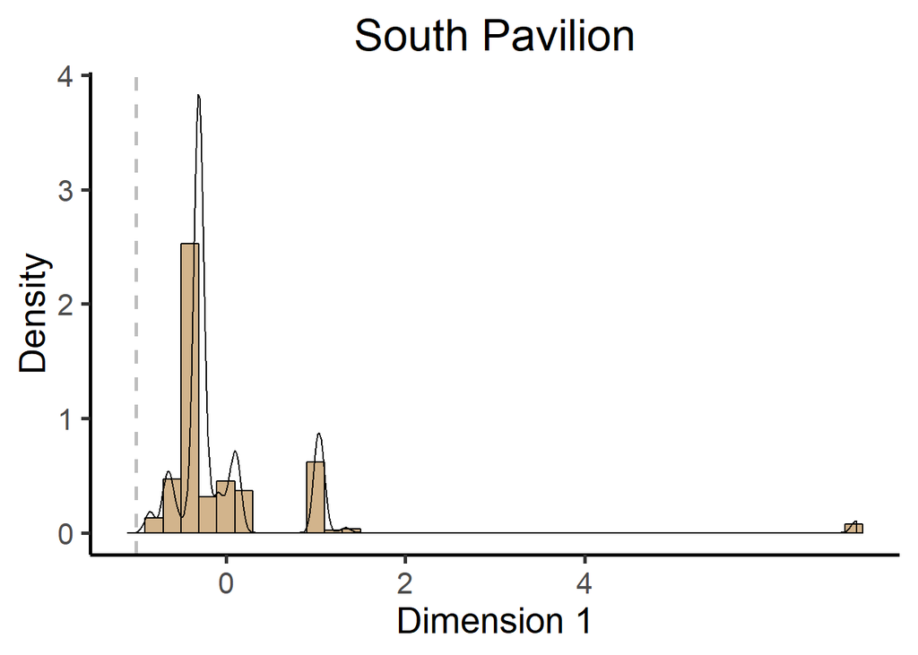

```r
p5a <- p5 + geom_vline(xintercept=c(-1), colour = "gray", linetype = "dashed",
                       size=1)
p5a
```

```r
ggsave("SouthPavilion_WeightedHist.jpg", p5a, width=10, height=7.5, dpi=300)
```

### 15. Dim 1 - MCD scatterplot with Phase assignments

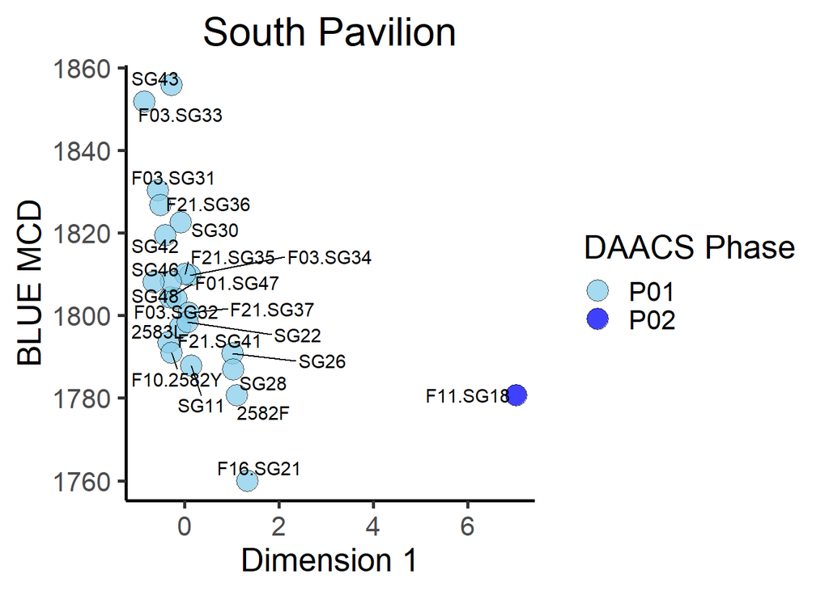

```r
CA_MCD_Phase <- CA_MCD %>% mutate(Phase = case_when (Dim1 <= 1.5 ~ 'P01',
                                                     #(Dim1 > -.4) &
                                                     #(Dim1 <= -1.2) ~ 'P02',
                                                     Dim1 > 1.5 ~ 'P02'
))
p6 <- ggplot(CA_MCD_Phase,aes(x = Dim1, y = blueMCD,
                              fill= Phase)) +
  #scale_y_continuous(limits=c(1750, 1950)) +
  geom_point(shape=21,  alpha = .75, size= 6)  +
  scale_fill_manual(name="DAACS Phase",
                    labels=c("P01", "P02"),
                    values=c("skyblue", "blue")) +
  geom_text_repel(aes(label= unit), cex=4) +
  theme(plot.title = element_text(hjust = 0.5))+
  labs(title="South Pavilion", x="Dimension 1", y="BLUE MCD")
p6
```

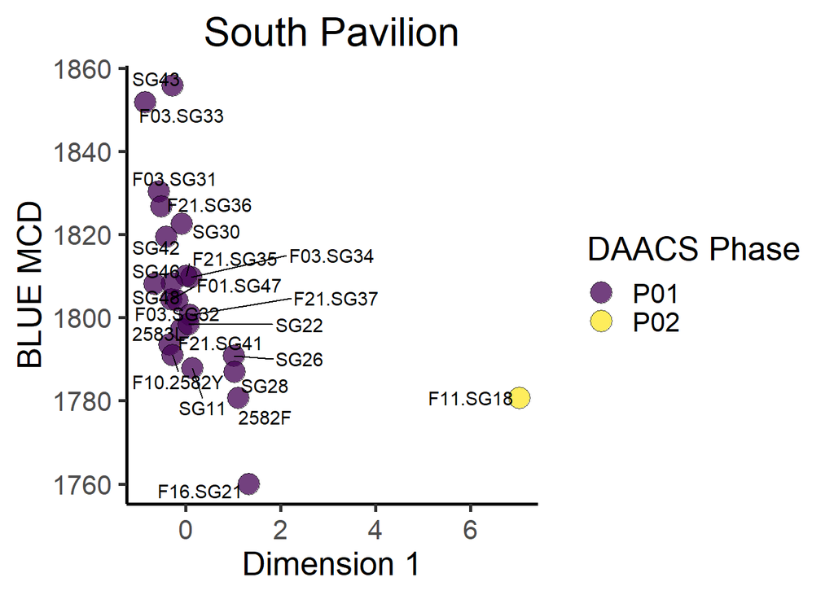

```r
ggsave("SPav_Dim1MCDcolor_2018.png", p6, width=10, height=7.5, dpi=300)
# And here we use viridis colors
p6a <- ggplot(CA_MCD_Phase,aes(x = Dim1,y = blueMCD, fill= factor(Phase))) +
  #scale_y_continuous(limits=c(1760, 1920)) +
  geom_point(shape=21,  alpha = .75, size= 6)  +
  scale_fill_viridis(discrete= T, name="DAACS Phase",
                     labels=c("P01", "P02")) +
  geom_text_repel(aes(label= unit), cex=4) +
  theme(plot.title = element_text(hjust = 0.5))+
  labs(title="South Pavilion", x="Dimension 1", y="BLUE MCD")
p6a
```

```r
ggsave("SPav_Dim1MCDcolor_2018.png", p6a, width=10, height=7.5, dpi=300)
```

### 16. Compute the MCDs and TPQs for the phases

- Join the Phases to the ware by unit data
- Compare assigned DAACS phases to the ones we came up with above and look for diffrences!

```r
unitPhase <- select(CA_MCD_Phase, unit, Phase)
wareByUnit_Phase<- left_join (wareTypeData_Unit, unitPhase, by = 'unit') %>%
  mutate(Phase = ifelse(is.na(Phase),'',Phase))
with(wareByUnit_Phase, table(DAACSPhase, Phase))
```

```
##           Phase
## DAACSPhase       P01  P02
##              59 1584   17
```

#### 16.1 Phase MCDs

- Transpose the data
- Apply the Estimate MCD function
- View results

```r
wareByPhaseT <- wareByUnit_Phase %>% group_by(Ware, Phase) %>%
  summarise(count = sum(Quantity)) %>%
  spread(Ware, value=count , fill=0 )
dataForMCD_Phase <- RemoveTypesNoDates(wareByPhaseT, MCDTypeTable)
MCDByPhase<-EstimateMCD(dataForMCD_Phase$unitData,
                        dataForMCD_Phase$typeData)
MCDByPhase
```

```
## $MCDs
##     Phase      MCD  blueMCD  TPQ TPQp95 TPQp90 Count
##           1803.398 1798.033 1840   1820   1820    54
## P01   P01 1822.305 1803.985 1840   1840   1820  1550
## P02   P02 1742.087 1780.663 1775   1775   1762    23
##
## $midPoints
##                        typeNames mPoint
## 1             American Stoneware 1835.0
## 2                   Astbury Type 1750.0
## 3                   Black Basalt 1785.0
## 4              British Stoneware 1735.5
## 5                   Buckley-type 1747.5
## 6                    Canary Ware 1807.5
## 7                      Creamware 1791.0
## 8       Delftware, Dutch/British 1701.0
## 9                    Fulham Type 1723.0
## 10       Ironstone/White Granite 1920.0
## 11                Jackfield Type 1765.0
## 12                     Pearlware 1802.5
## 13            Porcelain, Chinese 1760.0
## 14 Porcelain, English Bone China 1897.0
## 15      Porcellaneous/Hard Paste 1910.0
## 16                       Redware 1800.0
## 17              Redware, refined 1840.0
## 18                  Rosso Antico 1732.5
## 19    Tin-Enameled, unidentified 1701.0
## 20              White Salt Glaze 1762.5
## 21                     Whiteware 1910.0
## 22                   Yellow Ware 1885.0
```

### 17. Write out .csv contexts and phase assignments

- Use these later for inputting for the DAACS database

```r
phaseAssignments <- select(wareByUnit_Phase, ProjectName, ProjectID, Context, Phase)
phaseAssignments <- unique(phaseAssignments)
```